# The Human Smokestack: CO₂ Emissions, 1750–2025

Statistical reasoning and computational creativity with the Our World in Data CO₂ dataset

Your name(s) here

2026-11-23

# 1. The story

Part 5 uses the two artworks to answer the assignment’s two questions.

# 2. Analysis: the data science pipeline

## 2.1 Import

The data is Our World in Data’s CO₂ and Greenhouse Gas Emissions dataset (https://github.com/owid/co2-data). This document reads the copy of `owid-co2-data.csv` saved next to it. If that file is missing, it reads the latest version from GitHub instead.

```r
csv_path <- if (file.exists("owid-co2-data.csv")) "owid-co2-data.csv" else
  "https://raw.githubusercontent.com/owid/co2-data/master/owid-co2-data.csv"
co2 <- read_csv(csv_path, show_col_types = FALSE)

dim(co2)            # rows x columns
```

```
## [1] 56269    79
```

```r
range(co2$year)     # time span covered
```

```
## [1] 1750 2025
```

## 2.2 Inspect

Each row is one country or region in one year, with 79 columns. The columns used in this document are:

```r
co2 %>%
  select(country, year, iso_code, population, co2, coal_co2, oil_co2,
         gas_co2, cement_co2, flaring_co2, other_industry_co2,
         cumulative_co2, cumulative_co2_including_luc,
         temperature_change_from_co2) %>%
  glimpse()
```

```
## Rows: 56,269
## Columns: 14
## $ country                      <chr> "Afghanistan", "Afghanistan", "Afghanista…
## $ year                         <dbl> 1750, 1751, 1752, 1753, 1754, 1755, 1756,…
## $ iso_code                     <chr> "AFG", "AFG", "AFG", "AFG", "AFG", "AFG",…
## $ population                   <dbl> 2802560, NA, NA, NA, NA, NA, NA, NA, NA, …
## $ co2                          <dbl> NA, NA, NA, NA, NA, NA, NA, NA, NA, NA, N…
## $ coal_co2                     <dbl> NA, NA, NA, NA, NA, NA, NA, NA, NA, NA, N…
## $ oil_co2                      <dbl> NA, NA, NA, NA, NA, NA, NA, NA, NA, NA, N…
## $ gas_co2                      <dbl> NA, NA, NA, NA, NA, NA, NA, NA, NA, NA, N…
## $ cement_co2                   <dbl> 0, 0, 0, 0, 0, 0, 0, 0, 0, 0, 0, 0, 0, 0,…
## $ flaring_co2                  <dbl> NA, NA, NA, NA, NA, NA, NA, NA, NA, NA, N…
## $ other_industry_co2           <dbl> NA, NA, NA, NA, NA, NA, NA, NA, NA, NA, N…
## $ cumulative_co2               <dbl> NA, NA, NA, NA, NA, NA, NA, NA, NA, NA, N…
## $ cumulative_co2_including_luc <dbl> NA, NA, NA, NA, NA, NA, NA, NA, NA, NA, N…
## $ temperature_change_from_co2  <dbl> NA, NA, NA, NA, NA, NA, NA, NA, NA, NA, N…
```

```r
# how complete is the World series for each column we rely on?
co2 %>%
  filter(country == "World") %>%
  summarise(across(c(co2, coal_co2, oil_co2, gas_co2, cement_co2, flaring_co2,
                     cumulative_co2_including_luc, temperature_change_from_co2),
                   ~ paste(range(year[!is.na(.x)]), collapse = "–"))) %>%
  pivot_longer(everything(), names_to = "column", values_to = "years with data") %>%
  kable()
```

| column | years with data |
| --- | --- |
| co2 | 1750–2025 |
| coal_co2 | 1750–2025 |
| oil_co2 | 1855–2025 |
| gas_co2 | 1882–2025 |
| cement_co2 | 1818–2025 |
| flaring_co2 | 1950–2025 |
| cumulative_co2_including_luc | 1850–2025 |
| temperature_change_from_co2 | 1851–2024 |

All emissions are in **million tonnes of CO₂ (Mt)**. The `co2` column counts fossil fuels and industry only. Land-use change, such as deforestation, is counted separately.

## 2.3 Tidy

The file mixes real countries with aggregates such as “World”, “Africa”, “European Union (27)” and income groups. Adding them together would double count. Countries have a three-letter ISO code. Aggregates have either no code or an `OWID_` code, so the two can be separated cleanly.

```r
countries <- co2 %>%
  filter(!is.na(iso_code), !str_starts(iso_code, "OWID"))
world <- co2 %>% filter(country == "World")
last_year <- max(world$year[!is.na(world$co2)])

n_distinct(countries$country)   # number of countries
```

```
## [1] 223
```

```r
last_year
```

```
## [1] 2025
```

```r
# the six fossil/industrial sources, from wide columns to one long column
source_cols <- c(Coal = "coal_co2", Oil = "oil_co2", Gas = "gas_co2",
                 Cement = "cement_co2", Flaring = "flaring_co2",
                 Other = "other_industry_co2")
world_sources <- world %>%
  select(year, co2, all_of(source_cols)) %>%
  pivot_longer(-c(year, co2), names_to = "source", values_to = "mt") %>%
  # a missing source before it existed (oil before 1855, flaring before
  # 1950, ...) means no emissions from it, so 0
  mutate(mt = replace_na(mt, 0),
         source = factor(source, levels = names(source_cols)))

# sanity check: the six sources add up to the total in every year
world_sources %>%
  group_by(year, co2) %>%
  summarise(sum_sources = sum(mt), .groups = "drop") %>%
  summarise(largest_gap_mt = max(abs(sum_sources - co2)))
```

```
## # A tibble: 1 × 1
##   largest_gap_mt
##            <dbl>
## 1        0.00500
```

The six sources add up to the total to within a rounding error in every year, so the long table is safe to stack.

## 2.4 How fast did emissions grow, and from what?

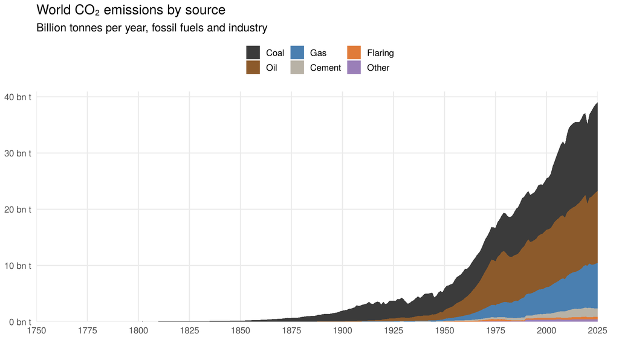

World CO₂ emissions from fossil fuels and industry by source, 1750–2025

```r
source_colors <- c(Coal = "#3b3b3b", Oil = "#8c5a2b", Gas = "#4a7fb0",
                   Cement = "#b8b2a6", Flaring = "#e07b39", Other = "#9a7fb8")

ggplot(world_sources, aes(year, mt / 1000, fill = source)) +
  geom_area(stat = "identity", color = NA) +
  scale_fill_manual(values = source_colors, name = NULL) +
  scale_x_continuous(breaks = seq(1750, 2025, by = 25), expand = c(0, 0)) +
  scale_y_continuous(labels = label_number(suffix = " bn t"), expand = expansion(mult = c(0, 0.05))) +
  labs(x = NULL, y = NULL,
       title = "World CO₂ emissions by source",
       subtitle = "Billion tonnes per year, fossil fuels and industry") +
  theme_minimal(base_size = 13) +
  theme(panel.grid.minor = element_blank(), legend.position = "top",
        plot.margin = margin(5, 25, 5, 5))
```

```r
first_last <- world_sources %>%
  filter(year %in% c(1900, 1950, last_year)) %>%
  group_by(year) %>%
  mutate(share = mt / sum(mt)) %>%
  ungroup() %>%
  select(year, source, share) %>%
  pivot_wider(names_from = year, values_from = share)
first_last %>% mutate(across(-source, percent_format(accuracy = 0.1))) %>% kable()
```

| source | 1900 | 1950 | 2025 |
| --- | --- | --- | --- |
| Coal | 95.7% | 65.5% | 40.3% |
| Oil | 3.4% | 26.1% | 32.9% |
| Gas | 0.6% | 6.0% | 20.7% |
| Cement | 0.3% | 1.1% | 3.8% |
| Flaring | 0.0% | 1.2% | 1.2% |
| Other | 0.0% | 0.1% | 1.0% |

To measure growth, a model of the form `log(co2) ~ year` is fitted to each historical period. The slope of that line is the average yearly growth rate, and `log(2) / slope` is the doubling time.

```r
periods <- tribble(
  ~period,                  ~from, ~to,
  "Industrial take-off",     1850, 1913,
  "Wars and depression",     1914, 1945,
  "Post-war boom",           1946, 1973,
  "Oil shocks to 2000",      1974, 2000,
  "21st century",            2001, last_year
)

growth <- periods %>%
  mutate(fit = map2(from, to, ~ lm(log(co2) ~ year,
                                   data = filter(world, year >= .x, year <= .y))),
         tidied = map(fit, ~ tidy(.x, conf.int = TRUE) %>% filter(term == "year")),
         r2 = map_dbl(fit, ~ glance(.x)$r.squared)) %>%
  unnest(tidied) %>%
  transmute(period, years = paste0(from, "–", to),
            growth = exp(estimate) - 1,
            ci_low = exp(conf.low) - 1, ci_high = exp(conf.high) - 1,
            doubling_years = log(2) / estimate, r2)

growth %>%
  mutate(across(c(growth, ci_low, ci_high), percent_format(accuracy = 0.1)),
         doubling_years = round(doubling_years),
         r2 = round(r2, 3)) %>%
  kable(col.names = c("Period", "Years", "Growth / yr", "95% CI low",
                      "95% CI high", "Doubling time (yrs)", "R²"))
```

| Period | Years | Growth / yr | 95% CI low | 95% CI high | Doubling time (yrs) | R² |
| --- | --- | --- | --- | --- | --- | --- |
| Industrial take-off | 1850–1913 | 4.6% | 4.5% | 4.6% | 16 | 0.996 |
| Wars and depression | 1914–1945 | 1.4% | 1.0% | 1.7% | 51 | 0.680 |
| Post-war boom | 1946–1973 | 4.7% | 4.5% | 4.8% | 15 | 0.995 |
| Oil shocks to 2000 | 1974–2000 | 1.6% | 1.4% | 1.7% | 45 | 0.957 |
| 21st century | 2001–2025 | 1.6% | 1.3% | 1.8% | 45 | 0.890 |

There were two bursts of very fast growth. From 1850 to 1913 emissions grew about 4.6% a year, doubling every 16 years, and the post-war boom matched it at 4.7%. Since the 1970s growth has slowed to about 1.6% a year. That is slower growth, but not a decline: on top of today’s base it still adds hundreds of millions of tonnes every year.

The confidence intervals assume each year is independent of the next. Emissions series are strongly autocorrelated, so the true uncertainty is wider than shown. The point estimates are the part to rely on.

## 2.5 Who emitted it?

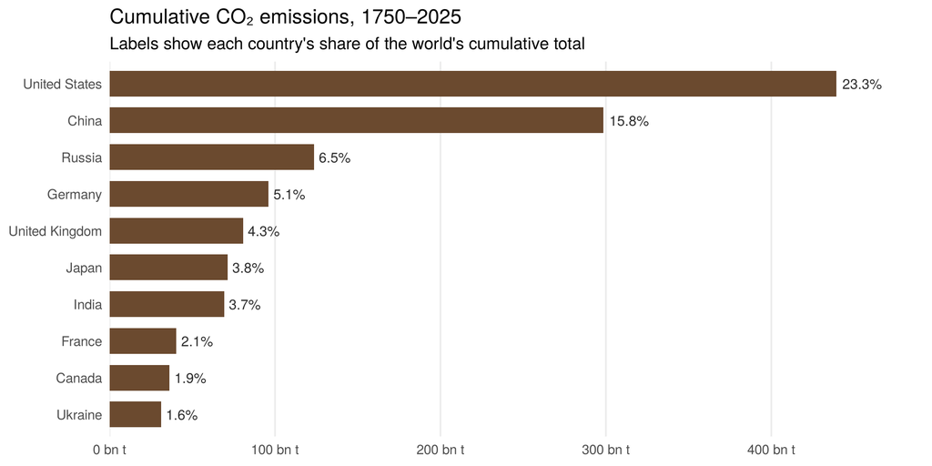

The ten countries with the largest cumulative CO₂ emissions, 1750–2025

```r
top10 <- countries %>%
  filter(year == last_year) %>%
  slice_max(cumulative_co2, n = 10) %>%
  mutate(country = fct_reorder(country, cumulative_co2))

top10_share <- sum(top10$share_global_cumulative_co2) / 100

ggplot(top10, aes(cumulative_co2 / 1000, country)) +
  geom_col(fill = "#6b4a2f", width = 0.7) +
  geom_text(aes(label = paste0(round(share_global_cumulative_co2, 1), "%")),
            hjust = -0.15, size = 3.8, color = "#2b2b2b") +
  scale_x_continuous(labels = label_number(suffix = " bn t"),
                     expand = expansion(mult = c(0, 0.12))) +
  labs(x = NULL, y = NULL,
       title = paste0("Cumulative CO₂ emissions, 1750–", last_year),
       subtitle = "Labels show each country's share of the world's cumulative total") +
  theme_minimal(base_size = 13) +
  theme(panel.grid.major.y = element_blank(), panel.grid.minor = element_blank())
```

Ten of the 223 countries account for 68% of all fossil CO₂ emitted since 1750. The United States alone accounts for 23.3%.

## 2.6 How unequal is it today?

A Lorenz curve answers this question. It ranks countries from lowest to highest emissions per person, then plots each group’s share of the world’s population against its share of the world’s emissions. The further the curve sags below the diagonal, the more unequal emissions are. The Gini coefficient summarises the sag in one number: 0 means everyone emits the same, and 1 means one person emits everything.

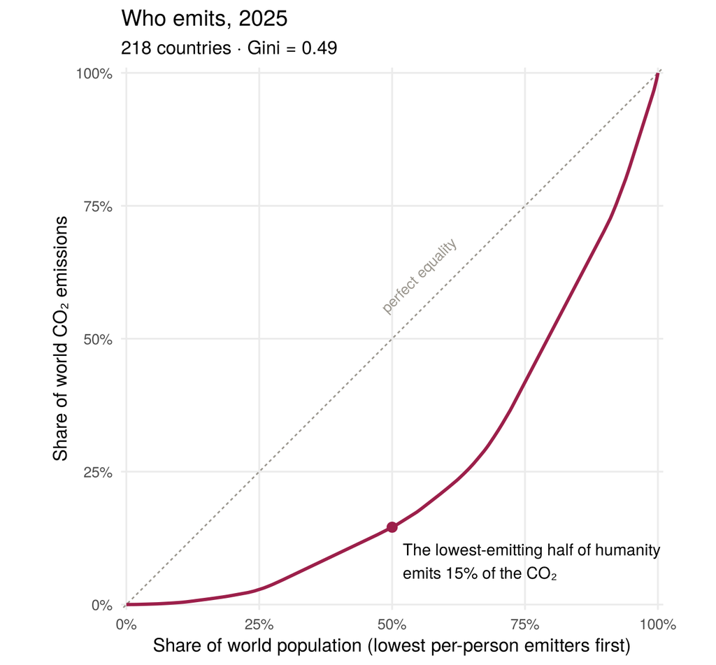

Lorenz curve of national per-person CO₂ emissions

```r
ineq <- countries %>%
  filter(year == last_year, !is.na(co2), !is.na(population), population > 0) %>%
  mutate(per_capita = co2 / population) %>%
  arrange(per_capita) %>%
  mutate(pop_share = cumsum(population) / sum(population),
         em_share  = cumsum(co2) / sum(co2))

lorenz <- bind_rows(tibble(pop_share = 0, em_share = 0),
                    select(ineq, pop_share, em_share))
gini <- 1 - sum(diff(lorenz$pop_share) *
                (head(lorenz$em_share, -1) + tail(lorenz$em_share, -1)))
bottom50 <- approx(lorenz$pop_share, lorenz$em_share, xout = 0.5)$y
top10pop <- 1 - approx(lorenz$pop_share, lorenz$em_share, xout = 0.9)$y

ggplot(lorenz, aes(pop_share, em_share)) +
  geom_abline(slope = 1, intercept = 0, linetype = "22", color = "#9a968e") +
  geom_line(linewidth = 1.1, color = "#9c1f4a") +
  annotate("point", x = 0.5, y = bottom50, size = 3, color = "#9c1f4a") +
  annotate("text", x = 0.52, y = bottom50 - 0.03, hjust = 0, vjust = 1, size = 4,
           label = paste0("The lowest-emitting half of humanity\nemits ",
                          percent(bottom50, 1), " of the CO₂")) +
  annotate("text", x = 0.55, y = 0.62, angle = 45, size = 3.6, color = "#9a968e",
           label = "perfect equality") +
  scale_x_continuous(labels = percent, expand = c(0, 0.01)) +
  scale_y_continuous(labels = percent, expand = c(0, 0.01)) +
  coord_equal() +
  labs(x = "Share of world population (lowest per-person emitters first)",
       y = "Share of world CO₂ emissions",
       title = paste0("Who emits, ", last_year),
       subtitle = paste0(nrow(ineq), " countries · Gini = ", round(gini, 2))) +
  theme_minimal(base_size = 13) +
  theme(panel.grid.minor = element_blank())
```

In 2025, the countries that hold the lowest-emitting half of the world’s population emitted only 15% of the CO₂. The highest-emitting tenth emitted 29%. This calculation treats every person in a country as emitting that country’s average. It cannot see inequality between people within the same country, so the true inequality between individuals is higher than this Gini of 0.49 suggests.

## 2.7 From emissions to warming

If the human contribution drives warming, warming should follow the cumulative total of CO₂ emitted, not each year’s emissions. This chunk regresses the dataset’s estimate of global warming caused by CO₂ on the world’s cumulative CO₂, including land-use change, for every year from 1851 to 2024.

```r
warm <- world %>%
  filter(!is.na(temperature_change_from_co2), !is.na(cumulative_co2_including_luc)) %>%
  mutate(cum_gt = cumulative_co2_including_luc / 1000)   # billion tonnes

warm_fit <- lm(temperature_change_from_co2 ~ cum_gt, data = warm)
tidy(warm_fit, conf.int = TRUE) %>% kable(digits = 6)
```

| term | estimate | std.error | statistic | p.value | conf.low | conf.high |
| --- | --- | --- | --- | --- | --- | --- |
| (Intercept) | 0.003654 | 0.000318 | 11.48876 | 0 | 0.003026 | 0.004282 |
| cum_gt | 0.000445 | 0.000000 | 1528.07125 | 0 | 0.000445 | 0.000446 |

```r
glance(warm_fit) %>% select(r.squared, sigma, nobs) %>% kable(digits = 5)
```

| r.squared | sigma | nobs |
| --- | --- | --- |
| 0.99993 | 0.0029 | 174 |

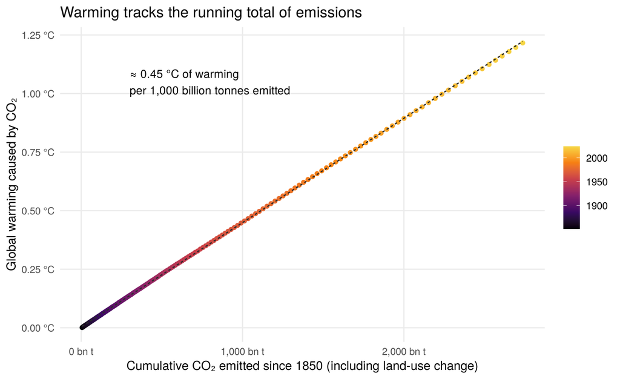

Estimated warming from CO₂ against cumulative CO₂ emitted, 1851–2024

```r
per_1000 <- coef(warm_fit)[["cum_gt"]] * 1000   # °C per 1,000 billion tonnes

ggplot(warm, aes(cum_gt, temperature_change_from_co2, color = year)) +
  geom_point(size = 1.8) +
  geom_smooth(method = "lm", se = FALSE, color = "#2b2b2b", linewidth = 0.6,
              linetype = "22") +
  scale_color_viridis_c(option = "inferno", end = 0.9, name = NULL) +
  scale_x_continuous(labels = label_number(big.mark = ",", suffix = " bn t")) +
  scale_y_continuous(labels = label_number(suffix = " °C")) +
  annotate("text", x = 300, y = 1.05, hjust = 0, size = 4.2,
           label = paste0("≈ ", round(per_1000, 2), " °C of warming\nper 1,000 billion tonnes emitted")) +
  labs(x = "Cumulative CO₂ emitted since 1850 (including land-use change)",
       y = "Global warming caused by CO₂",
       title = "Warming tracks the running total of emissions") +
  theme_minimal(base_size = 13) +
  theme(panel.grid.minor = element_blank())
```

The relationship is almost perfectly straight (R² = 0.9999). Each 1,000 billion tonnes of CO₂ adds about **0.45 °C** of warming. This matches the IPCC’s best estimate of about 0.45 °C per 1,000 billion tonnes, its “transient climate response to cumulative emissions”. By 2024 humans had emitted 2,736 billion tonnes, which by this relationship accounts for about 1.22 °C of warming.

The near-perfect R² needs care. OWID did not measure this temperature column with thermometers. It estimated it from emissions with a simple climate model, so a strong fit is partly built in. What the regression shows is that the dataset is internally consistent with established climate science. It does not prove that relationship independently. Observed warming also includes effects from methane, nitrous oxide and aerosols.

# 3. Artwork for the eye: *The Human Smokestack*

The first artwork turns sections 2.4 to 2.6 into a single image. A streamgraph pours out of a factory chimney in 1950 and keeps widening to 2025. Each band is a region. Its thickness in any year is that region’s emissions, and its numbers at the right edge are its 2025 emissions and its total since 1950. The chimney’s smoke runs straight into the bands. The metaphor is that every band is smoke from the same stack, and the stack is human industry.

The sections below build the artwork step by step.

### 3.1 The time span and the series

The artwork reuses the `co2` table imported in Part 2. It starts in 1950, when every region has a recorded value in every year, and runs to the last year in the file.

```r
# the full range of the dataset: first to last year with a World figure
Y0 <- 1950   # chart start (the dataset itself starts in 1750)
Y1 <- max(co2$year[co2$country == "World" & !is.na(co2$co2)])

# when each series used below starts and ends in the file
sources <- c("United Kingdom", "European Union (27)", "United States", "China",
             "India", "Russia", "Japan", "Canada", "Africa", "South America",
             "Asia", "World")
coverage <- co2 %>%
  filter(country %in% sources, !is.na(co2)) %>%
  group_by(country) %>%
  summarise(first = min(year), last = max(year), .groups = "drop") %>%
  arrange(first)
coverage
```

```
## # A tibble: 12 × 3
##    country             first  last
##    <chr>               <dbl> <dbl>
##  1 Asia                 1750  2025
##  2 India                1750  2025
##  3 United Kingdom       1750  2025
##  4 World                1750  2025
##  5 Canada               1785  2025
##  6 European Union (27)  1792  2025
##  7 United States        1800  2025
##  8 Russia               1830  2025
##  9 South America        1844  2025
## 10 Japan                1868  2025
## 11 Africa               1884  2025
## 12 China                1907  2025
```

```r
# one country/region's annual CO2 (Mt) for every year Y0..Y1.
# Before a series' first recorded year it has no recorded emissions, so 0;
# the occasional missing year inside a series is filled in linearly
# from the years either side.
get_series <- function(name) {
  d <- co2 %>% filter(country == name, year >= Y0, year <= Y1, !is.na(co2))
  v <- approx(d$year, d$co2, xout = Y0:Y1, rule = 1)$y
  v[Y0:Y1 < min(d$year)] <- 0
  v
}
```

### 3.2 Building the twelve categories

The chart follows the same regional breakdown a lot of “CO2 through time” explainers use: seven individual countries (the UK included, since it is the whole story before 1800), the EU-27 as a bloc, two continental aggregates, and two remainder categories so everything still sums to the real world total in every single year.

```r
china  <- get_series("China")
us     <- get_series("United States")
india  <- get_series("India")
russia <- get_series("Russia")
japan  <- get_series("Japan")
canada <- get_series("Canada")
uk     <- get_series("United Kingdom")
eu     <- get_series("European Union (27)")   # OWID's own current-members aggregate
africa <- get_series("Africa")                 # OWID continent aggregate
sam    <- get_series("South America")          # OWID continent aggregate
asia   <- get_series("Asia")                   # OWID continent aggregate
world_v <- get_series("World")

# Asia minus the three Asian countries already broken out on their own
asia_excl <- asia - china - india - japan

# whatever is left once every named category is subtracted from the world
# total (Oceania, non-EU Europe, the rest of the Americas, etc.)
named_sum <- china + us + india + russia + japan + canada + uk + eu + africa + sam + asia_excl
rest_of_world <- world_v - named_sum

# OWID's aggregates and country series come from slightly different sources
# in the earliest years, so the remainder can dip a hair below zero there.
# Check it is negligible, then clip it.
stopifnot(min(rest_of_world) > -0.02 * max(world_v))
rest_of_world <- pmax(rest_of_world, 0)

years <- Y0:Y1

# stacking order, bottom -> top
order <- c("China", "Asia (excl. China, India, Japan)", "United States",
           "European Union", "United Kingdom", "Rest of World", "India", "Russia",
           "Africa", "South America", "Japan", "Canada")

mat <- rbind(china, asia_excl, us, eu, uk, rest_of_world, india, russia, africa,
             sam, japan, canada)
rownames(mat) <- order
n <- nrow(mat); m <- ncol(mat)
```

### 3.3 A wiggle-free “silhouette” streamgraph baseline

A streamgraph is a stacked area chart whose baseline floats instead of sitting at zero, so the whole stack reads as a symmetric, organically expanding band rather than a wall rising off the x-axis. The classic ThemeRiver construction centers the stack at every year:

```r
totals <- colSums(mat)
baseline <- -totals / 2   # symmetric baseline: top = +total/2, bottom = -total/2

ymin_mat <- matrix(0, n, m)
ymax_mat <- matrix(0, n, m)
cum <- baseline
for (i in seq_len(n)) {
  ymin_mat[i, ] <- cum
  cum <- cum + mat[i, ]
  ymax_mat[i, ] <- cum
}
rownames(ymin_mat) <- order
rownames(ymax_mat) <- order

long <- lapply(seq_len(n), function(i) {
  tibble(year = years, category = order[i],
         ymin = ymin_mat[i, ], ymax = ymax_mat[i, ], thickness = mat[i, ])
}) %>%
  bind_rows() %>%
  mutate(category = factor(category, levels = order))
```

### 3.4 Colors, and automatic label contrast

Each band keeps one fixed color. Rather than hand-pick a text color per label, we compute the [relative luminance](https://www.w3.org/TR/WCAG20/#relativeluminancedef) of each band’s color and choose black or cream text automatically — this is what lets every country name sit *directly inside* its own colored band cleanly, instead of needing a separate legend.

```r
colors <- c(
  "China" = "#9c1f4a", "Asia (excl. China, India, Japan)" = "#d98c82",
  "United States" = "#1a6fa3", "European Union" = "#f2c230",
  "United Kingdom" = "#6b4a2f",
  "Rest of World" = "#a6a6a6", "India" = "#e2863a", "Russia" = "#2437d6",
  "Africa" = "#1f6b3a", "South America" = "#8a3b8f", "Japan" = "#f3b8c4",
  "Canada" = "#2f9e8f"
)

text_color_for <- function(hex) {
  rgb <- col2rgb(hex) / 255
  lin <- ifelse(rgb <= 0.03928, rgb / 12.92, ((rgb + 0.055) / 1.055)^2.4)
  L <- 0.2126 * lin[1] + 0.7152 * lin[2] + 0.0722 * lin[3]
  if (L > 0.45) "#1a1a1a" else "#f5f1e6"
}
label_colors <- setNames(vapply(colors, text_color_for, character(1)), names(colors))

# A few band colors (pale pink, pale sand) work fine as fills but read poorly
# as *text* against the cream page background. Darken just the text variant
# for those — the ribbon, connector lines, and legend dots keep the true color.
darken_label <- function(hex, amt = 0.35) {
  rgb <- col2rgb(hex) / 255
  if (mean(rgb) > 0.62) rgb <- rgb * (1 - amt)
  rgb(rgb[1], rgb[2], rgb[3])
}
text_colors <- setNames(vapply(colors, darken_label, character(1)), names(colors))
```

### 3.5 Placing the labels: inside the band, or above it

The names are set in one straight column near the right end of the stream (see the next section), each centered in its own band, the way the reference infographic does it. The helpers below are kept for the label search used elsewhere in the document.

```r
thin_categories <- c("Canada", "Japan", "South America")

window_df <- long %>% filter(year >= 1995, year <= Y1 - 7)
best <- window_df %>%
  group_by(category) %>%
  slice_max(thickness, n = 1, with_ties = FALSE) %>%
  ungroup() %>%
  mutate(mid = (ymin + ymax) / 2,
         is_thin = category %in% thin_categories,
         label = ifelse(category == "Asia (excl. China, India, Japan)",
                         "Asia (excl. China,\nIndia, Japan)", as.character(category)))

max_total <- max(totals)
BG <- "#f5f1e6"  # warm off-white background, matches the reference infographic

direct <- best %>% filter(!is_thin)

pointer <- best %>%
  filter(is_thin) %>%
  mutate(year = c(Canada = 2019, Japan = 2011, `South America` = 1998)[as.character(category)]) %>%
  rowwise() %>%
  mutate(mid = {
    i <- which(order == as.character(category))
    j <- which(years == year)
    (ymin_mat[i, j] + ymax_mat[i, j]) / 2
  }) %>%
  ungroup() %>%
  mutate(label_y = max_total * 0.60)
```

### 3.6 Each band’s numbers, attached to the end of the band

Rather than a separate table that repeats every name, each region’s numbers are written right where its band ends in 2025, in the band’s own color, set right against the band’s end. The color and the position are the link. Both figures come straight out of `mat`: the last column for the 2025 value, `rowSums(mat)` for the 1950–2025 total, in billions of tonnes.

```r
# Same y-envelope the plot uses (coord_cartesian below)
ylim_lo <- -max_total * 0.66
ylim_hi <- max_total * 0.74
axis_y  <- ylim_lo + max_total * 0.015
axis_ticks <- seq(Y0, Y1, by = 10)

latest_val <- setNames(mat[, m] / 1000, order)      # billions of t, in Y1
cum_val    <- setNames(rowSums(mat) / 1000, order)  # billions of t, Y0-Y1

end_df <- tibble(
  category = factor(order, levels = order),           # China (bottom) ... Canada (top)
  target   = (ymin_mat[, m] + ymax_mat[, m]) / 2,     # middle of each band in Y1
  v1       = latest_val[order],
  v2       = cum_val[order],
  col      = unname(colors[order]),
  txt      = unname(text_colors[order])
)

# Each row sits level with its own band. Where thin bands are too close for
# two lines of text, push rows upward just enough to clear each other; the
# connector still starts at the band's true position.
min_gap <- max_total * 0.021
y <- end_df$target
for (i in 2:length(y)) y[i] <- max(y[i], y[i - 1] + min_gap)
end_df$y <- y

num_v1 <- Y1 + 0.6     # this year's value, right against the band's end
num_v2 <- Y1 + 5.0    # cumulative value
div_x  <- Y1 + 4.4    # thin divider between the two columns
head_y <- max(end_df$y) + min_gap * 2.2
x_max  <- Y1 + 10

# Names: one straight column, centered at name_x, each at the middle of its
# own band in that year. Bands thick enough get the name inside (smaller type
# for the thin ones); a band too thin for any text gets it just above.
name_x <- 2014       # a flat stretch before the 2020 dip
win <- which(years >= name_x - 4 & years <= name_x + 4)   # years the name text spans
name_df <- tibble(
  category = factor(order, levels = order),
  label    = recode(order, "Asia (excl. China, India, Japan)" = "Asia\n(excl. China,\nIndia, Japan)",
                    "Rest of World" = "Rest of\nWorld", "European Union" = "European\nUnion",
                    "United Kingdom" = "U.K.",
                    "United States" = "U.S."),
  # average middle of the band across those years, so the name sits squarely
  # in its own band even where the band slopes or dips (2020)
  y        = rowMeans((ymin_mat[, win] + ymax_mat[, win]) / 2),
  ymax     = apply(ymax_mat[, win], 1, max),
  thick    = apply(mat[, win], 1, min),
  col      = unname(colors[order]),
  txt      = unname(text_colors[order])
) %>%
  mutate(inside = thick >= 800 & !category %in% c("South America", "United Kingdom"),
         fs     = case_when(category == "Asia (excl. China, India, Japan)" ~ 3.9, thick >= 4000 ~ 4.6, thick >= 2500 ~ 4.0, thick >= 1300 ~ 3.0, TRUE ~ 2.7))

# South America's name is too long for its thin band, and the U.K.'s band is
# too thin for any text, so both get a pointer: the name above the stream and
# a thin line down into the band
make_pointer <- function(cat, yr, lab) {
  i <- which(order == cat); j <- which(years == yr)
  tibble(x = yr, label = lab,
         y_mid = (ymin_mat[i, j] + ymax_mat[i, j]) / 2,
         y_lab = totals[j] / 2 + max_total * 0.085,
         col = colors[[cat]], txt = text_colors[[cat]])
}
sa_pointer <- bind_rows(make_pointer("South America", 1984, "South America"),
                        make_pointer("United Kingdom", 2001, "United Kingdom"))
```

### 3.7 The three call-out facts (kept entirely off the colors)

These sit in the blank cream background to either side of the thin early stream (1950s) — never on top of a colored band — with a thin leader line running from the text down (or up) to the data point it describes.

```r
env_top <- function(yr) totals[years == yr] / 2
env_bot <- function(yr) -totals[years == yr] / 2

# Every number in the three call-outs is computed here from the data.
total_over <- function(name, yrs) sum(co2$co2[co2$country == name & co2$year %in% yrs], na.rm = TRUE)

# 1. the 1950s, and everything emitted before 1950 (1750-1949)
fifties  <- 1950:1959
before50 <- 1750:1949
us_50s     <- total_over("United States", fifties) / total_over("World", fifties)
europe_50s <- (total_over("European Union (27)", fifties) + total_over("United Kingdom", fifties)) /
  total_over("World", fifties)
west_pre50 <- (total_over("United States", before50) + total_over("European Union (27)", before50) +
  total_over("United Kingdom", before50)) / total_over("World", before50)

# 2. China, 1950 -> 1980
china_1950   <- china[years == 1950]
china_1980   <- china[years == 1980]
china_growth <- round((china_1980 / china_1950 - 1) * 100)
china_fold   <- round(china_1980 / china_1950)

# 3. today: the three largest emitting countries, and the rest of Asia as a group
top3_share <- (china[years == Y1] + us[years == Y1] + india[years == Y1]) / world_v[years == Y1]
asia_share <- asia_excl[years == Y1] / world_v[years == Y1]

# check that China, the U.S. and India really are the three largest countries
countries_now <- co2 %>% filter(year == Y1, !is.na(iso_code), !str_starts(iso_code, "OWID"))
stopifnot(identical(sort(slice_max(countries_now, co2, n = 3)$country),
                    sort(c("China", "United States", "India"))))

# a bracket under the text spanning the 1950s, with an arrow from it down
# into the middle of the U.S. band in 1955
us_mid_1955 <- long %>% filter(category == "United States", year == 1955) %>%
  mutate(mid = (ymin + ymax) / 2) %>% pull(mid)
ann1 <- list(x = 1952, y = 12200,
             bracket_x = c(1950, 1959), bracket_y = 9000,
             arrow_x = 1955, arrow_yend = us_mid_1955,
             label = sprintf(paste0("In the 1950s, the U.S. and Europe (EU-27 + U.K.)\n",
                                    "emitted %s of the world's CO\u2082."),
                             percent(us_50s + europe_50s, 1)))

ann2 <- list(x = 1952, y = -13600, xstart = 1961, ystart = -12900,
             xend = 1969, yend = env_bot(1969) * 1.03,
             label = sprintf(paste0("Between 1950 and 1980, China's yearly emissions grew\n",
                                    "%s-fold (+%s%%), from %s to %s billion tonnes."),
                             china_fold, format(china_growth, big.mark = ""),
                             round(china_1950 / 1000, 2), round(china_1980 / 1000, 1)))

ann3 <- list(x = 1952, y = -18600,
             label = sprintf(paste0("Today, three countries (China, the U.S. and India)\n",
                                    "emit %s of the world's CO\u2082. The rest of Asia,\n",
                                    "taken together, emits another %s."),
                             percent(top3_share, 1), percent(asia_share, 1)))

# 4. the line under the title: what came before the chart starts
pre_years   <- min(co2$year[co2$country == "World" & !is.na(co2$co2)]):(Y0 - 1)
all_years   <- min(pre_years):Y1
pre_total   <- total_over("World", pre_years)
pre_share   <- pre_total / total_over("World", all_years)
pre_groups  <- c(
  "the U.S."      = total_over("United States", pre_years),
  "the EU-27"     = total_over("European Union (27)", pre_years),
  "the U.K."      = total_over("United Kingdom", pre_years),
  "Russia"        = total_over("Russia", pre_years),
  "China"         = total_over("China", pre_years),
  "India"         = total_over("India", pre_years),
  "Japan"         = total_over("Japan", pre_years),
  "Canada"        = total_over("Canada", pre_years),
  "Africa"        = total_over("Africa", pre_years),
  "South America" = total_over("South America", pre_years),
  "the rest of Asia" = total_over("Asia", pre_years) - total_over("China", pre_years) -
                       total_over("India", pre_years) - total_over("Japan", pre_years)
) / pre_total
pre_top <- sort(pre_groups, decreasing = TRUE)[1:3]          # the three largest groups
pre_top_txt <- paste0(names(pre_top), " (", percent(pre_top, 1), ")")
intro_line <- sprintf(paste0("The record begins in %d. By %d the world had already emitted %s billion tonnes, ",
                             "%s of everything emitted to date,\nmostly by %s, %s and %s."),
                      min(pre_years), Y0, comma(round(pre_total / 1000)), percent(pre_share, 1),
                      pre_top_txt[1], pre_top_txt[2], pre_top_txt[3])
intro_line
```

```
## [1] "The record begins in 1750. By 1950 the world had already emitted 226 billion tonnes, 12% of everything emitted to date,\nmostly by the U.S. (40%), the EU-27 (28%) and the U.K. (17%)."
```

```r
flags <- tibble(lab = c("CN", "US", "IN"),
                 col = c(colors[["China"]], colors[["United States"]], colors[["India"]]),
                 x = c(1952, 1954.3, 1956.6))
```

### 3.8 The smokestack the stream comes out of

The chimney photo (`chimney.png`, saved next to this file) stands at the left edge, with its smoke running straight into the start of the stream in 1950. The photo is placed so its plume sits level with the stream’s start, its base sits on the time axis, and it keeps its own proportions. The stream is drawn on top, so the colored bands come out of the smoke.

```r
chimney_img <- png::readPNG("chimney.png")
img_ratio <- dim(chimney_img)[1] / dim(chimney_img)[2]   # height / width in pixels

smoke_frac <- 0.18          # the plume's middle, as a share of the photo's height from the top
stack_H    <- -axis_y / (1 - smoke_frac)                    # photo height in data units
stack_ymax <- smoke_frac * stack_H
stack_ymin <- axis_y

# convert the photo's height into a width in years, using the panel's size
# in inches, so it isn't stretched
panel_w_in <- 17.0; panel_h_in <- 8.6
x_range <- (x_max - (Y0 - 7.5)); y_range <- ylim_hi - ylim_lo
stack_h_in <- stack_H / y_range * panel_h_in
stack_w    <- (stack_h_in / img_ratio) / panel_w_in * x_range
stack_xmax <- Y0 + 1.0       # smoke tucks just under the stream's first year
stack_xmin <- stack_xmax - stack_w

smoke_end <- Y0 + 2          # (used to drop band outlines inside the smoke)
```

### 3.9 The plot

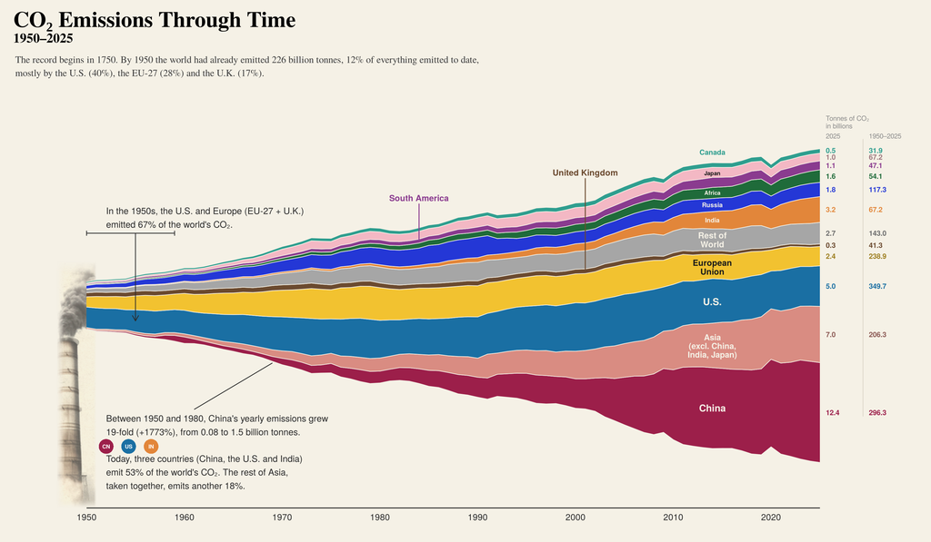

CO2 emissions through time, by region, 1950-2025, each band labeled with its own totals (Our World in Data)

```r
ggplot(long, aes(x = year, ymin = ymin, ymax = ymax, fill = category)) +
  # chimney photo, drawn first so the stream sits on top of its smoke
  annotation_raster(chimney_img, xmin = stack_xmin, xmax = stack_xmax,
                    ymin = stack_ymin, ymax = stack_ymax, interpolate = TRUE) +
  # the stream: the same thin cream separators between bands in every year
  geom_ribbon(color = BG, linewidth = 0.4) +
  scale_fill_manual(values = colors, guide = "none") +
  scale_x_continuous(expand = c(0, 0)) +

  # one straight column of names near the right end, each inside its band
  geom_text(data = filter(name_df, inside),
            aes(x = name_x, y = y, label = label, color = category, size = fs),
            inherit.aes = FALSE, family = "sans", fontface = "bold", lineheight = 0.88) +
  scale_color_manual(values = label_colors, guide = "none") +
  scale_size_identity() +
  # the one band too thin to hold its name (Canada) gets it just above its top edge
  geom_segment(data = sa_pointer, aes(x = x, xend = x, y = y_mid, yend = y_lab - max_total * 0.008),
               inherit.aes = FALSE, linewidth = 0.6, color = sa_pointer$col) +
  geom_text(data = sa_pointer, aes(x = x, y = y_lab, label = label),
            inherit.aes = FALSE, fontface = "bold", size = 4.0, vjust = 0, color = sa_pointer$txt) +
  geom_text(data = filter(name_df, category == "Canada"),
            aes(x = name_x, y = ymax + max_total * 0.008, label = label),
            inherit.aes = FALSE, fontface = "bold", size = 3.4, vjust = 0,
            color = filter(name_df, category == "Canada")$txt) +

  # call-out annotations, entirely in the cream background
  annotate("segment", x = ann1$bracket_x[1], xend = ann1$bracket_x[2],
           y = ann1$bracket_y, yend = ann1$bracket_y, linewidth = 0.5, color = "#2b2b2b") +
  annotate("segment", x = ann1$bracket_x, xend = ann1$bracket_x,
           y = ann1$bracket_y - max_total * 0.008, yend = ann1$bracket_y + max_total * 0.008,
           linewidth = 0.5, color = "#2b2b2b") +
  annotate("segment", x = ann1$arrow_x, xend = ann1$arrow_x,
           y = ann1$bracket_y, yend = ann1$arrow_yend, linewidth = 0.5, color = "#2b2b2b",
           arrow = arrow(length = unit(0.12, "inches"), type = "open")) +
  annotate("text", x = ann1$x, y = ann1$y, label = ann1$label, hjust = 0, vjust = 1,
           size = 4.3, family = "sans", color = "#2b2b2b", lineheight = 1.25) +
  annotate("segment", x = ann2$xstart, y = ann2$ystart, xend = ann2$xend, yend = ann2$yend,
           linewidth = 0.5, color = "#2b2b2b") +
  annotate("text", x = ann2$x, y = ann2$y, label = ann2$label, hjust = 0, vjust = 1,
           size = 4.3, family = "sans", color = "#2b2b2b", lineheight = 1.25) +
  annotate("text", x = ann3$x, y = ann3$y, label = ann3$label, hjust = 0, vjust = 1,
           size = 4.3, family = "sans", color = "#2b2b2b", lineheight = 1.25) +
  geom_point(data = flags, aes(x = x, y = -17500), inherit.aes = FALSE, shape = 16,
             size = 9, color = flags$col) +
  geom_text(data = flags, aes(x = x, y = -17500, label = lab), inherit.aes = FALSE,
            size = 2.6, fontface = "bold", color = "white") +

  # bottom axis, drawn by hand so it can sit below the floating baseline
  annotate("segment", x = Y0, xend = Y1, y = axis_y, yend = axis_y, linewidth = 0.6,
           color = "#2b2b2b") +
  annotate("text", x = axis_ticks, y = axis_y - max_total * 0.018,
           label = axis_ticks, size = 4.2, vjust = 1, color = "#2b2b2b", family = "sans") +

  # numbers set right against the end of each band, in the band's color
  geom_text(data = end_df, aes(x = num_v1, y = y, label = number(v1, accuracy = 0.1)),
            inherit.aes = FALSE, hjust = 0, fontface = "bold", size = 3.4, color = end_df$txt) +
  geom_text(data = end_df, aes(x = num_v2, y = y, label = number(v2, accuracy = 0.1)),
            inherit.aes = FALSE, hjust = 0, fontface = "bold", size = 3.4, color = end_df$txt) +
  annotate("segment", x = div_x, xend = div_x, y = head_y - min_gap * 0.45,
           yend = min(end_df$y) - min_gap * 0.6, linewidth = 0.3, color = "#cfc8b8") +
  annotate("text", x = num_v1, y = head_y + min_gap * 1.15,
           label = "Tonnes of CO\u2082\nin billions", hjust = 0, vjust = 0, size = 3.2,
           color = "#8a8a8a", lineheight = 0.95, family = "sans") +
  annotate("text", x = num_v1, y = head_y, label = as.character(Y1), hjust = 0,
           size = 3.2, color = "#8a8a8a", family = "sans") +
  annotate("text", x = num_v2, y = head_y, label = paste0(Y0, "\u2013", Y1), hjust = 0,
           size = 3.2, color = "#8a8a8a", family = "sans") +

  # the line under the title about the years before 1950
  annotate("text", x = Y0 - 7.3, y = ylim_hi + max_total * 0.055, label = intro_line, hjust = 0, vjust = 1,
           size = 4.6, family = "serif", color = "#3a3a3a", lineheight = 1.15) +
  coord_cartesian(clip = "off", xlim = c(Y0 - 7.5, x_max), ylim = c(ylim_lo, ylim_hi)) +
  labs(title = "CO₂ Emissions Through Time",
       subtitle = paste0(Y0, "–", Y1)) +
  theme_void(base_size = 14) +
  theme(
    plot.background  = element_rect(fill = BG, color = NA),
    panel.background = element_rect(fill = BG, color = NA),
    plot.margin      = margin(16, 18, 10, 18),
    plot.title    = element_text(face = "bold", size = 30, hjust = 0, family = "serif",
                                  margin = margin(b = 2)),
    plot.subtitle = element_text(face = "bold", size = 18, hjust = 0, family = "serif",
                                  margin = margin(b = 8)),
    plot.caption  = element_blank()
  )
```

# 4. Artwork for the ear: *Breath of the Chimney*

A chart shows the whole period at once, so a reader can see that emissions rose without feeling how quickly. Sound plays out in time, so a listener experiences it as it happens. *Breath of the Chimney* compresses 1850–2025 into about half a minute. Each year lasts 0.15 seconds. Four layers carry the data:

| Layer | What you hear | Data it carries |
| --- | --- | --- |
| Smoke | filtered noise, like a roaring chimney or wind | world CO₂ each year → loudness |
| Three voices | an A-major chord (A3, C♯4, E4) | U.S., EU-27 and China CO₂ → loudness of each note |
| Warming drone | a low hum that slowly rises in pitch | warming from CO₂ → pitch (one octave per 0.5 °C) |
| Clock | a soft tick | the start of every decade |

The noise suits emissions because CO₂ is invisible and shapeless: it reads as a roar rather than a note. Each emitter’s note follows its own history. The U.S. note (A3) swells early, the EU-27 note (C♯4) swells and then fades, and the China note (E4) is silent until the 1950s before overpowering the others. The pitch of the drone is never reset, because warming accumulates the same way cumulative emissions do.

## 4.1 Build the score

The score is a table with one row per year. Each column is a layer expressed as a share of the loudest year, from 0 to 1.

```r
son_years <- 1850:last_year

# a country's yearly series on son_years. Years before its first record
# count as 0; the warming series stops at 2024, so its last value is held.
yearly <- function(name, var = "co2") {
  d <- co2 %>% filter(country == name, !is.na(.data[[var]]))
  v <- approx(d$year, d[[var]], xout = son_years, rule = 2)$y
  v[son_years < min(d$year)] <- 0
  v
}

score <- tibble(
  year  = son_years,
  world = yearly("World"),
  us    = yearly("United States"),
  eu    = yearly("European Union (27)"),
  china = yearly("China"),
  temp  = yearly("World", "temperature_change_from_co2")
)
peak <- max(score$world)

score %>%
  filter(year %in% c(1850, 1900, 1950, 2000, last_year)) %>%
  mutate(across(c(world, us, eu, china), ~ round(.x / peak, 3)),
         temp = round(temp, 2)) %>%
  kable(col.names = c("Year", "Smoke loudness", "U.S. note", "EU-27 note",
                      "China note", "Warming (°C)"))
```

| Year | Smoke loudness | U.S. note | EU-27 note | China note | Warming (°C) |
| --- | --- | --- | --- | --- | --- |
| 1850 | 0.005 | 0.001 | 0.001 | 0.000 | 0.00 |
| 1900 | 0.050 | 0.017 | 0.018 | 0.000 | 0.10 |
| 1950 | 0.152 | 0.065 | 0.033 | 0.002 | 0.30 |
| 2000 | 0.654 | 0.154 | 0.092 | 0.094 | 0.80 |
| 2025 | 1.000 | 0.129 | 0.062 | 0.318 | 1.22 |

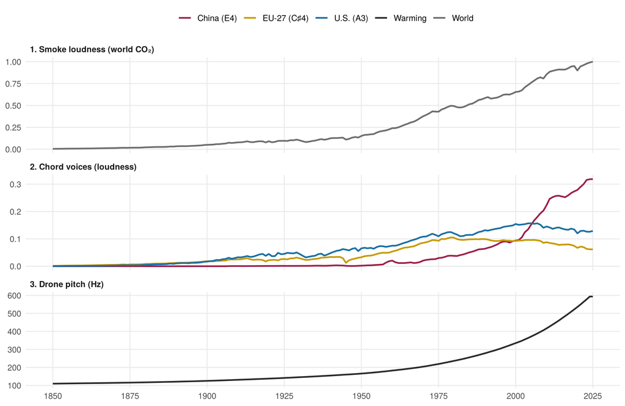

The score: what each layer of the sound does over time

```r
score_long <- bind_rows(
  score %>% transmute(year, layer = "1. Smoke loudness (world CO₂)", voice = "World", value = world / peak),
  score %>% transmute(year, layer = "2. Chord voices (loudness)", voice = "U.S. (A3)", value = us / peak),
  score %>% transmute(year, layer = "2. Chord voices (loudness)", voice = "EU-27 (C♯4)", value = eu / peak),
  score %>% transmute(year, layer = "2. Chord voices (loudness)", voice = "China (E4)", value = china / peak),
  score %>% transmute(year, layer = "3. Drone pitch (Hz)", voice = "Warming", value = 110 * 2^(temp / 0.5))
)
voice_colors <- c("World" = "#6e6e6e", "U.S. (A3)" = colors[["United States"]],
                  "EU-27 (C♯4)" = "#c79a00", "China (E4)" = colors[["China"]],
                  "Warming" = "#2b2b2b")

ggplot(score_long, aes(year, value, color = voice)) +
  geom_line(linewidth = 0.9) +
  facet_wrap(~ layer, ncol = 1, scales = "free_y") +
  scale_color_manual(values = voice_colors, name = NULL) +
  scale_x_continuous(breaks = seq(1850, 2025, by = 25)) +
  labs(x = NULL, y = NULL) +
  theme_minimal(base_size = 12) +
  theme(panel.grid.minor = element_blank(), legend.position = "top",
        strip.text = element_text(face = "bold", hjust = 0))
```

## 4.2 Synthesise the sound

The sound is built sample by sample in base R. A tone is a sine wave, the smoke is smoothed random noise, and each layer’s loudness follows the score smoothly from one year to the next. The result is saved as a standard 16-bit WAV file, `co2_breath.wav`, with no audio packages required.

```r
sr <- 22050                     # samples per second
sec_per_year <- 0.15
n <- round(length(son_years) * sec_per_year * sr)
t_sec <- (0:(n - 1)) / sr
yr <- son_years[1] + t_sec / sec_per_year           # the year at each sample
at <- function(v) approx(score$year, v, xout = yr, rule = 2)$y

# 1. smoke: smoothed noise, loudness = world emissions
set.seed(1)
noise <- as.numeric(stats::filter(rnorm(n), rep(1 / 12, 12), circular = TRUE))
smoke <- 0.30 * at(score$world / peak) * noise / sd(noise)

# 2. the chord: one note per emitter, loudness = its emissions
tone <- function(freq, amp) amp * sin(2 * pi * freq * t_sec)
voices <- tone(220.00, 0.30 * at(score$us    / peak)) +
          tone(277.18, 0.30 * at(score$eu    / peak)) +
          tone(329.63, 0.30 * at(score$china / peak))

# 3. the drone: pitch rises one octave per 0.5 °C of CO₂-driven warming
f_drone <- 110 * 2^(at(score$temp) / 0.5)
drone <- 0.05 * sin(2 * pi * cumsum(f_drone) / sr)

# 4. the clock: a short tick at every decade
tick <- numeric(n)
for (dec in son_years[son_years %% 10 == 0]) {
  i0 <- round((dec - son_years[1]) * sec_per_year * sr) + 1
  k <- 0:round(0.03 * sr)
  idx <- i0 + k
  keep <- idx <= n
  tick[idx[keep]] <- tick[idx[keep]] +
    0.25 * exp(-k[keep] / (0.006 * sr)) * sin(2 * pi * 1500 * k[keep] / sr)
}

mix <- smoke + voices + drone + tick
mix <- mix * pmin(1, t_sec / 0.5, (max(t_sec) - t_sec) / 1.0)   # fade in / out
mix <- 0.9 * mix / max(abs(mix))

write_wav <- function(x, path, sr) {
  pcm <- as.integer(round(x * 32767))
  nbytes <- length(pcm) * 2
  con <- file(path, "wb"); on.exit(close(con))
  writeChar("RIFF", con, eos = NULL); writeBin(as.integer(36 + nbytes), con, size = 4, endian = "little")
  writeChar("WAVEfmt ", con, eos = NULL); writeBin(16L, con, size = 4, endian = "little")
  writeBin(c(1L, 1L), con, size = 2, endian = "little")                 # PCM, mono
  writeBin(c(as.integer(sr), as.integer(sr * 2)), con, size = 4, endian = "little")
  writeBin(c(2L, 16L), con, size = 2, endian = "little")                # block align, bits
  writeChar("data", con, eos = NULL); writeBin(as.integer(nbytes), con, size = 4, endian = "little")
  writeBin(pcm, con, size = 2, endian = "little")
}
write_wav(mix, "co2_breath.wav", sr)

# how loud is each part of the piece? (root-mean-square level per 25 years)
tibble(year = floor(yr / 25) * 25, x = mix) %>%
  group_by(from = year) %>%
  summarise(loudness_rms = round(sqrt(mean(x^2)), 3)) %>%
  kable()
```

| from | loudness_rms |
| --- | --- |
| 1850 | 0.028 |
| 1875 | 0.030 |
| 1900 | 0.036 |
| 1925 | 0.041 |
| 1950 | 0.079 |
| 1975 | 0.139 |
| 2000 | 0.197 |
| 2025 | 0.021 |

## 4.3 Listen

[interactive chart not shown]

*26 seconds. The decade ticks mark time: one tick every 1.5 seconds.*

What to listen for:

- **1850–1945:** a quiet hiss, with the U.S. and EU-27 notes slowly coming through. The first doubling took 16 years, but from a small base, so it is easy to miss.
- **1946–1973:** the post-war boom. The hiss swells quickly and the U.S. and EU-27 notes ring together.
- **1980s onward:** the EU-27 note fades, and the China note grows until it is louder than both others (from the mid-2000s). By the end, the roar has drowned out the ticks.
- **The whole piece:** the drone rises slowly and never comes back down. Warming is the one layer that does not drop when emissions do, because it follows the running total.

# 5. Reflection

## 5.1 Can data art reveal patterns that conventional visualisation cannot?

Partly. Neither artwork shows a fact that the analysis in Part 2 does not also contain: the growth rates, the shares and the warming slope are all in the tables. But both artworks make some patterns much harder to miss.

The cost is precision. Nobody can hear “15.5 years” or read 296.3 billion tonnes off the width of a band. That is why the streamgraph writes its numbers at the end of each band, and why this document keeps the regression tables next to the artworks. Data art is a way into the data, not a replacement for analysing it.

## 5.2 Is emotional understanding a legitimate form of understanding data?

Yes, with conditions. Understanding includes knowing what matters and why, not only knowing the numbers. Someone who can recite that the lowest-emitting half of humanity emits 15% of the CO₂, but has never felt that this is unequal, has not fully understood the number. Climate change is a problem about scale, accumulation and fairness. Those are exactly the things that numbers alone tend to flatten and that artwork can bring back.

Emotional understanding is only legitimate if the feeling is earned honestly, and these artworks follow four rules to make sure it is:

1. **The emotion has to come from the data.** Every visual and sonic choice is computed from the CSV. The width of the stream, the loudness of the roar and the pitch of the drone are all data, not decoration.
2. **The encodings must not exaggerate.** Loudness and band width are both proportional to emissions, with no exaggerated scales and no cherry-picked start years. The early decades are quiet because they really were smaller.
3. **The limits must be stated.** Sections 2.4, 2.6 and 2.7 explain the autocorrelation in the growth model, the per-country averaging behind the Gini, and the fact that the warming series comes from a model.
4. **The art should lead back to the analysis.** The artwork makes people care, and the statistics let them check. A feeling that cannot be traced back to the numbers is manipulation, not understanding.

Used this way, data art does not replace analysis. It helps the findings reach people who would never read a regression table.

# 6. Summary of findings

- World fossil CO₂ emissions rose from 197 million tonnes in 1850 to 38,995 million tonnes in 2025. Growth peaked twice: about 4.6% a year in 1850–1913 and 4.7% a year in 1946–1973.
- Ten countries account for 68% of cumulative emissions since 1750.
- In 2025 the lowest-emitting half of the world’s population emitted 15% of the CO₂. The Gini coefficient across countries is 0.49.
- In this dataset, warming from CO₂ rises by about 0.45 °C per 1,000 billion tonnes emitted, in line with the IPCC’s estimate.

**Data and files.** The analysis uses Our World in Data, *CO₂ and Greenhouse Gas Emissions* (https://github.com/owid/co2-data), from the `owid-co2-data.csv` in this folder. To knit this document, keep `owid-co2-data.csv` and `chimney.png` in the same folder as the `.Rmd`. Knitting writes `co2_breath.wav` to that folder.